# SK_01_BOND_ISSUE_PURPOSE_DESC

Description of purpose · Text report

## Overview

**Description**

Description of purpose

**Table**

`SK-P01-T01-BOND-ISSUES` (many)

**Location code**

`SCHED-K-PART-01-COL-F`

**Family**

`SCHED-K-PART-01-COL-F`

**Data type**

text (xsd: LineExplanationType)

**Scope**

PC

**Status**

unreviewed

2

xpaths mapped (2 observed)

87,964

filings with a value

2009–2024

tax years observed

2

open flags (0 errors)

## Flags

| Severity | Flag | Xpath | Detail |
| --- | --- | --- | --- |
| ⓘ info | `MANY_NOT_REPEATING` | IRS990ScheduleK/TaxExemptBondsIssuesGrp/PurposeDesc | many-to-one table, but 57% of values sit in no repeating element |
| ⓘ info | `MANY_NOT_REPEATING` | IRS990ScheduleK/Form990ScheduleKPartI/DescriptionOfPurpose | many-to-one table, but 57% of values sit in no repeating element |

## Xpaths

All mapped xpaths (under /Return/ReturnData or /Return/ReturnHeader), oldest first. Charts label each series by its xpath.

| Xpath | Form | First year | Last year | Versions | Filings | Repeats in |
| --- | --- | --- | --- | --- | --- | --- |
| IRS990ScheduleK/Form990ScheduleKPartI/DescriptionOfPurpose | Sched K | 2009 | 2012 | 18 | 19,466 | 41.3% |
| IRS990ScheduleK/TaxExemptBondsIssuesGrp/PurposeDesc | Sched K | 2013 | 2024 | 37 | 68,498 | 40.6% |

## Coverage

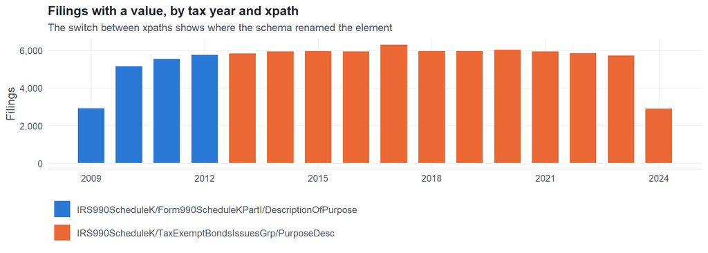

**Table view**

Table view: filings by tax year and series

| Tax year | IRS990ScheduleK/Form990ScheduleKPartI/DescriptionOfPurpose | IRS990ScheduleK/TaxExemptBondsIssuesGrp/PurposeDesc |
| --- | --- | --- |
| 2009 | 2,944 | 0 |
| 2010 | 5,171 | 0 |
| 2011 | 5,569 | 0 |
| 2012 | 5,782 | 0 |
| 2013 | 0 | 5,841 |
| 2014 | 0 | 5,953 |
| 2015 | 0 | 5,966 |
| 2016 | 0 | 5,950 |
| 2017 | 0 | 6,310 |
| 2018 | 0 | 5,980 |
| 2019 | 0 | 5,968 |
| 2020 | 0 | 6,047 |
| 2021 | 0 | 5,959 |
| 2022 | 0 | 5,861 |
| 2023 | 0 | 5,733 |
| 2024 | 0 | 2,930 |

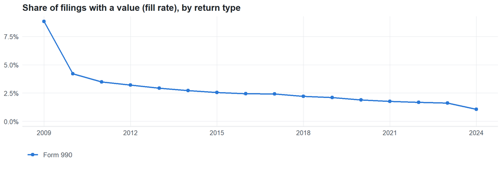

**Table view**

Table view: fill rate

| Tax year | Return type | Filings | All filings | Fill rate |
| --- | --- | --- | --- | --- |
| 2009 | Form 990 | 2,944 | 33,311 | 8.84% |
| 2010 | Form 990 | 5,171 | 123,025 | 4.20% |
| 2011 | Form 990 | 5,569 | 159,504 | 3.49% |
| 2012 | Form 990 | 5,782 | 179,688 | 3.22% |
| 2013 | Form 990 | 5,841 | 198,855 | 2.94% |
| 2014 | Form 990 | 5,953 | 218,619 | 2.72% |
| 2015 | Form 990 | 5,966 | 233,519 | 2.55% |
| 2016 | Form 990 | 5,950 | 243,903 | 2.44% |
| 2017 | Form 990 | 6,310 | 261,612 | 2.41% |
| 2018 | Form 990 | 5,980 | 271,442 | 2.20% |
| 2019 | Form 990 | 5,968 | 283,694 | 2.10% |
| 2020 | Form 990 | 6,047 | 320,342 | 1.89% |
| 2021 | Form 990 | 5,959 | 336,480 | 1.77% |
| 2022 | Form 990 | 5,861 | 349,055 | 1.68% |
| 2023 | Form 990 | 5,733 | 354,768 | 1.62% |
| 2024 | Form 990 | 2,930 | 277,298 | 1.06% |

## Repeating groups

Table cardinality in the concordance: **many**. 2 of 2 observed xpaths repeat within a filing.

Repeating element each xpath was observed in (from the raw indexed xpath)

| Xpath | Repeating element | Filings (summed over years) |
| --- | --- | --- |
| IRS990ScheduleK/Form990ScheduleKPartI/DescriptionOfPurpose | (none) | 11408 |
| IRS990ScheduleK/Form990ScheduleKPartI/DescriptionOfPurpose | IRS990ScheduleK | 466 |
| IRS990ScheduleK/Form990ScheduleKPartI/DescriptionOfPurpose | IRS990ScheduleK/Form990ScheduleKPartI | 8040 |
| IRS990ScheduleK/TaxExemptBondsIssuesGrp/PurposeDesc | (none) | 40540 |
| IRS990ScheduleK/TaxExemptBondsIssuesGrp/PurposeDesc | IRS990ScheduleK | 2221 |
| IRS990ScheduleK/TaxExemptBondsIssuesGrp/PurposeDesc | IRS990ScheduleK/TaxExemptBondsIssuesGrp | 27919 |

## Values

| Result | Check | Detail |
| --- | --- | --- |
| ✓ pass | Values are text, not numbers | 0% of values are numeric |
| ✓ pass | No dominant boilerplate value | most common value covers 6% of filings: “SEE PART VI” |
| ⓘ info | No sign of truncation | IRS990ScheduleK/Form990ScheduleKPartI/DescriptionOfPurpose: longest value is exactly 100 characters; IRS990ScheduleK/TaxExemptBondsIssuesGrp/PurposeDesc: longest value is exactly 100 characters |

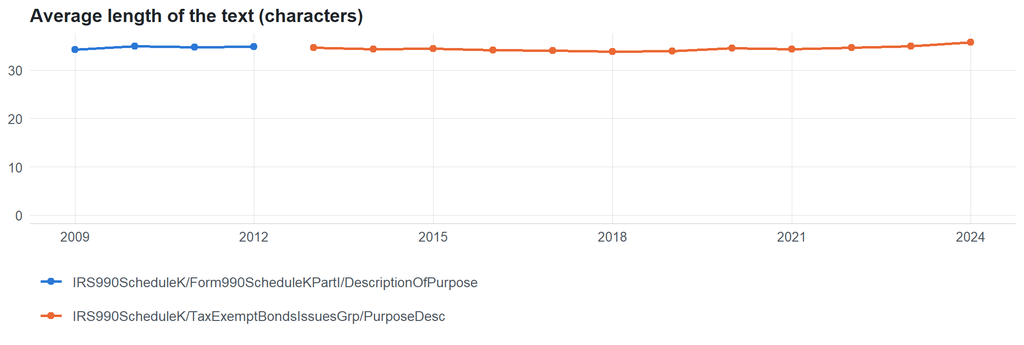

**Table view**

Table view: length and variety by tax year

| Series | Tax year | Filings | Avg length | Max length | Distinct values (approx.) |
| --- | --- | --- | --- | --- | --- |
| IRS990ScheduleK/Form990ScheduleKPartI/DescriptionOfPurpose | 2009 | 2,944 | 34 | 100 | 3,178 |
| IRS990ScheduleK/Form990ScheduleKPartI/DescriptionOfPurpose | 2010 | 5,171 | 35 | 100 | 4,230 |
| IRS990ScheduleK/Form990ScheduleKPartI/DescriptionOfPurpose | 2011 | 5,569 | 35 | 100 | 4,153 |
| IRS990ScheduleK/Form990ScheduleKPartI/DescriptionOfPurpose | 2012 | 5,782 | 35 | 100 | 5,359 |
| IRS990ScheduleK/TaxExemptBondsIssuesGrp/PurposeDesc | 2013 | 5,841 | 35 | 100 | 4,260 |
| IRS990ScheduleK/TaxExemptBondsIssuesGrp/PurposeDesc | 2014 | 5,953 | 34 | 100 | 4,734 |
| IRS990ScheduleK/TaxExemptBondsIssuesGrp/PurposeDesc | 2015 | 5,966 | 34 | 100 | 5,378 |
| IRS990ScheduleK/TaxExemptBondsIssuesGrp/PurposeDesc | 2016 | 5,950 | 34 | 100 | 5,886 |
| IRS990ScheduleK/TaxExemptBondsIssuesGrp/PurposeDesc | 2017 | 6,310 | 34 | 100 | 5,671 |
| IRS990ScheduleK/TaxExemptBondsIssuesGrp/PurposeDesc | 2018 | 5,980 | 34 | 100 | 5,567 |
| IRS990ScheduleK/TaxExemptBondsIssuesGrp/PurposeDesc | 2019 | 5,968 | 34 | 100 | 3,642 |
| IRS990ScheduleK/TaxExemptBondsIssuesGrp/PurposeDesc | 2020 | 6,047 | 34 | 100 | 3,537 |
| IRS990ScheduleK/TaxExemptBondsIssuesGrp/PurposeDesc | 2021 | 5,959 | 34 | 100 | 6,019 |
| IRS990ScheduleK/TaxExemptBondsIssuesGrp/PurposeDesc | 2022 | 5,861 | 35 | 100 | 8,263 |
| IRS990ScheduleK/TaxExemptBondsIssuesGrp/PurposeDesc | 2023 | 5,733 | 35 | 100 | 5,942 |
| IRS990ScheduleK/TaxExemptBondsIssuesGrp/PurposeDesc | 2024 | 2,930 | 36 | 100 | 1,757 |

Most common values by xpath (all years; long values truncated)

| Series | Value | Filings | Share |
| --- | --- | --- | --- |
| IRS990ScheduleK/Form990ScheduleKPartI/DescriptionOfPurpose | SEE SCHEDULE O | 322 | 1.7% |
| IRS990ScheduleK/Form990ScheduleKPartI/DescriptionOfPurpose | SEE PART VI | 285 | 1.5% |
| IRS990ScheduleK/Form990ScheduleKPartI/DescriptionOfPurpose | CONSTRUCTION | 248 | 1.3% |
| IRS990ScheduleK/Form990ScheduleKPartI/DescriptionOfPurpose | SEE PART V | 227 | 1.2% |
| IRS990ScheduleK/Form990ScheduleKPartI/DescriptionOfPurpose | See Schedule O | 146 | 0.8% |
| IRS990ScheduleK/Form990ScheduleKPartI/DescriptionOfPurpose | CAPITAL IMPROVEMENTS | 128 | 0.7% |
| IRS990ScheduleK/Form990ScheduleKPartI/DescriptionOfPurpose | See Part VI | 82 | 0.4% |
| IRS990ScheduleK/Form990ScheduleKPartI/DescriptionOfPurpose | REFINANCE | 79 | 0.4% |
| IRS990ScheduleK/Form990ScheduleKPartI/DescriptionOfPurpose | BUILDING CONSTRUCTION | 66 | 0.3% |
| IRS990ScheduleK/Form990ScheduleKPartI/DescriptionOfPurpose | See Part V | 51 | 0.3% |
| IRS990ScheduleK/Form990ScheduleKPartI/DescriptionOfPurpose | Construction | 42 | 0.2% |
| IRS990ScheduleK/Form990ScheduleKPartI/DescriptionOfPurpose | CAPITAL PROJECTS | 40 | 0.2% |
| IRS990ScheduleK/Form990ScheduleKPartI/DescriptionOfPurpose | SEE SUPPLEMENTAL INFORMATION | 32 | 0.2% |
| IRS990ScheduleK/Form990ScheduleKPartI/DescriptionOfPurpose | REFINANCING | 23 | 0.1% |
| IRS990ScheduleK/Form990ScheduleKPartI/DescriptionOfPurpose | CAPITAL EXPENDITURES | 21 | 0.1% |
| IRS990ScheduleK/Form990ScheduleKPartI/DescriptionOfPurpose | REFINANCE EXISTING DEBT | 14 | 0.1% |
| IRS990ScheduleK/Form990ScheduleKPartI/DescriptionOfPurpose | Refund prior issue | 13 | 0.1% |
| IRS990ScheduleK/Form990ScheduleKPartI/DescriptionOfPurpose | SEE SCH O | 13 | 0.1% |
| IRS990ScheduleK/Form990ScheduleKPartI/DescriptionOfPurpose | See Schedule O. | 12 | 0.1% |
| IRS990ScheduleK/TaxExemptBondsIssuesGrp/PurposeDesc | SEE PART VI | 4,059 | 5.9% |
| IRS990ScheduleK/TaxExemptBondsIssuesGrp/PurposeDesc | CONSTRUCTION | 893 | 1.3% |
| IRS990ScheduleK/TaxExemptBondsIssuesGrp/PurposeDesc | See Part VI | 740 | 1.1% |
| IRS990ScheduleK/TaxExemptBondsIssuesGrp/PurposeDesc | SEE SUPPLEMENTAL INFORMATION | 419 | 0.6% |
| IRS990ScheduleK/TaxExemptBondsIssuesGrp/PurposeDesc | CAPITAL IMPROVEMENTS | 404 | 0.6% |
| IRS990ScheduleK/TaxExemptBondsIssuesGrp/PurposeDesc | REFUNDING | 354 | 0.5% |
| IRS990ScheduleK/TaxExemptBondsIssuesGrp/PurposeDesc | CAPITAL EXPENDITURES | 327 | 0.5% |
| IRS990ScheduleK/TaxExemptBondsIssuesGrp/PurposeDesc | REFINANCE | 266 | 0.4% |
| IRS990ScheduleK/TaxExemptBondsIssuesGrp/PurposeDesc | REFINANCING | 179 | 0.3% |
| IRS990ScheduleK/TaxExemptBondsIssuesGrp/PurposeDesc | CAPITAL PROJECTS | 175 | 0.3% |
| IRS990ScheduleK/TaxExemptBondsIssuesGrp/PurposeDesc | SEE SCHEDULE O | 116 | 0.2% |

First rows shown.

## Examples

| Tax year | Return | Xpath | Organization | Value | Source |
| --- | --- | --- | --- | --- | --- |
| 2024 | 990 | IRS990ScheduleK/TaxExemptBondsIssuesGrp/PurposeDesc | RISEWELL COMMUNITY SERVICES INC FKA | REFINANCE 00 & 10 BOND | [XML](https://gt990datalake-rawdata.s3.amazonaws.com/EfileData/XmlFiles/202610589349301811_public.xml) |
| 2023 | 990 | IRS990ScheduleK/TaxExemptBondsIssuesGrp/PurposeDesc | Heritage Community Charter School Inc | Facilities Acquisition | [XML](https://gt990datalake-rawdata.s3.amazonaws.com/EfileData/XmlFiles/202402569349300885_public.xml) |
| 2022 | 990 | IRS990ScheduleK/TaxExemptBondsIssuesGrp/PurposeDesc | LUTHERAN HOME OF JAMAICA PLAIN INC | BUILDING PURCHASE | [XML](https://gt990datalake-rawdata.s3.amazonaws.com/EfileData/XmlFiles/202431279349301533_public.xml) |
| 2021 | 990 | IRS990ScheduleK/TaxExemptBondsIssuesGrp/PurposeDesc | MARY ANN MORSE HEALTHCARE CORP | REFINANCE AND EXPANSION / RENOVATIONS | [XML](https://gt990datalake-rawdata.s3.amazonaws.com/EfileData/XmlFiles/202232659349301608_public.xml) |
| 2020 | 990 | IRS990ScheduleK/TaxExemptBondsIssuesGrp/PurposeDesc | METROPOLITAN MONTESSORI SCHOOL | SEE PART VI | [XML](https://gt990datalake-rawdata.s3.amazonaws.com/EfileData/XmlFiles/202241369349310589_public.xml) |
| 2019 | 990 | IRS990ScheduleK/TaxExemptBondsIssuesGrp/PurposeDesc | ST ANNE’S EPISCOPAL SCHOOL INC | REFUNDING | [XML](https://gt990datalake-rawdata.s3.amazonaws.com/EfileData/XmlFiles/202101269349301820_public.xml) |
| 2018 | 990 | IRS990ScheduleK/TaxExemptBondsIssuesGrp/PurposeDesc | NEW ENGLAND BAPTIST HOSPITAL | SEE PART VI | [XML](https://gt990datalake-rawdata.s3.amazonaws.com/EfileData/XmlFiles/202042319349300104_public.xml) |
| 2017 | 990 | IRS990ScheduleK/TaxExemptBondsIssuesGrp/PurposeDesc | GREATER JAMAICA DEVELOPMENT CORPORATION | PROPERTY ACQUISITION, CONSTRUCTION AND IMPROVEMENTS | [XML](https://gt990datalake-rawdata.s3.amazonaws.com/EfileData/XmlFiles/201813199349301766_public.xml) |
| 2016 | 990 | IRS990ScheduleK/TaxExemptBondsIssuesGrp/PurposeDesc | COMPASS INC | DEFEASE PORTION OF PRIOR MORTGAGE AND PROVIDE FUNDS FOR NEW HOME PURCHASE | [XML](https://gt990datalake-rawdata.s3.amazonaws.com/EfileData/XmlFiles/201841149349300244_public.xml) |
| 2015 | 990 | IRS990ScheduleK/TaxExemptBondsIssuesGrp/PurposeDesc | ESARC INC | PURCHASE OF AND IMPROVEMENTS TO LAND & BUILDING | [XML](https://gt990datalake-rawdata.s3.amazonaws.com/EfileData/XmlFiles/201643199349307379_public.xml) |
| 2014 | 990 | IRS990ScheduleK/TaxExemptBondsIssuesGrp/PurposeDesc | UNIVERSITY OF DAYTON | CURRENT REFUNDING AND ADVANCE REFUNDING OF PRIOR ISSUES | [XML](https://gt990datalake-rawdata.s3.amazonaws.com/EfileData/XmlFiles/201611179349300316_public.xml) |
| 2013 | 990 | IRS990ScheduleK/TaxExemptBondsIssuesGrp/PurposeDesc | HUDSON HOSPITAL INC | REFUNDING OF SERIES 2002 BONDS | [XML](https://gt990datalake-rawdata.s3.amazonaws.com/EfileData/XmlFiles/201433189349302323_public.xml) |

## Reviewer checklist

- The definition matches the form line and instructions for every xpath’s schema years.
- Every xpath pooled here measures the same thing on the 990 and 990-EZ (close enough for analysis).
- The coverage chart has no unexplained gaps or jumps between tax years.
- Each open flag is fixed, or accepted with a note in validation_log.csv.
- Values answer the question on the form line (not another line’s explanation).
- Boilerplate such as ‘See Schedule O’ or ‘N/A’ is expected here, or should be treated as missing.
- Text that is really a number or a code is flagged for a different data type.

Record the review as a row in `inst/extdata/src/validation_log.csv` (variable_name, reviewer, date, status, note). Evidence built 2026-09-23 17:09:04 MST from the ef2 DuckDB builds, TY2009–2024.